# An Introduction to emojifont package

Guangchuang Yu

2026-02-27

# emojifont: using emoji font in R

The emojifont package is designed to bring emoji font to R users. It packs emoji fonts and uses showtext to render the fonts so they can be used in base plots or ggplot2.

## Installation

Get the released version from CRAN:

```r
install.packages("emojifont")
```

Or the development version from GitHub:

```r
## install.packages("devtools")
devtools::install_github("GuangchuangYu/emojifont")
```

# Emoji characters

To use emoji, we need to use their corresponding unicode. Emoji unicode can be found in https://apps.timwhitlock.info/emoji/tables/unicode, or searched using `search_emoji`. `search_emoji` returns emoji aliases which can be converted to unicode by `emoji`.

```r
search_emoji("smile")
```

```
[1] "smiley"      "smile"       "sweat_smile" "smiley_cat"  "smile_cat"
```

```r
emoji(search_emoji("smile"))
```

```
[1] "😃" "😄" "😅" "😺" "😸"
```

# Emoji in R plot

## base plot

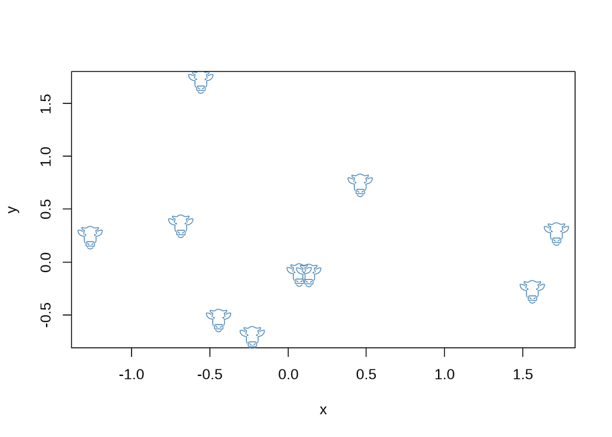

```r
set.seed(123)
x <- rnorm(10)
set.seed(321)
y <- rnorm(10)
plot(x, y, cex = 0)
text(x, y, labels = emoji("cow"), cex = 1.5, col = "steelblue", family = "OpenMoji")
```

## ggplot2

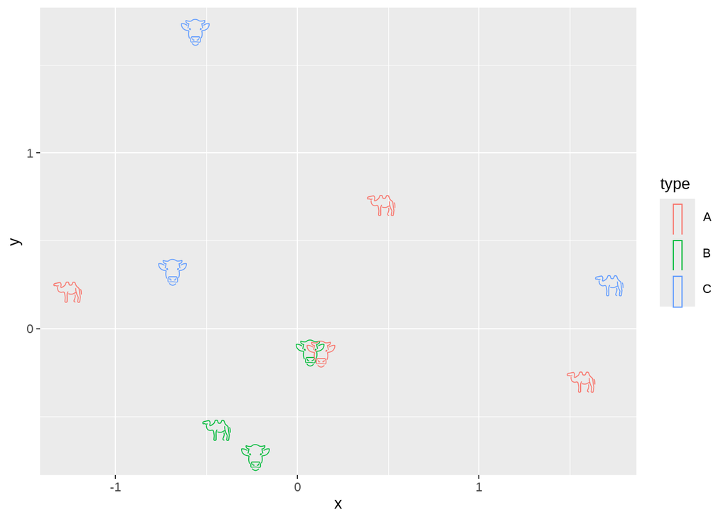

```r
d <- data.frame(
  x = x, y = y,
  label = sample(c(emoji("cow"), emoji("camel")), 10, replace = TRUE),
  type = sample(LETTERS[1:3], 10, replace = TRUE)
)

library(ggplot2)
ggplot(d, aes(x, y, color = type, label = label)) +
  geom_text(family = "OpenMoji", size = 6)
```

To make it easy to use with ggplot2, a simple layer `geom_emoji` is provided.

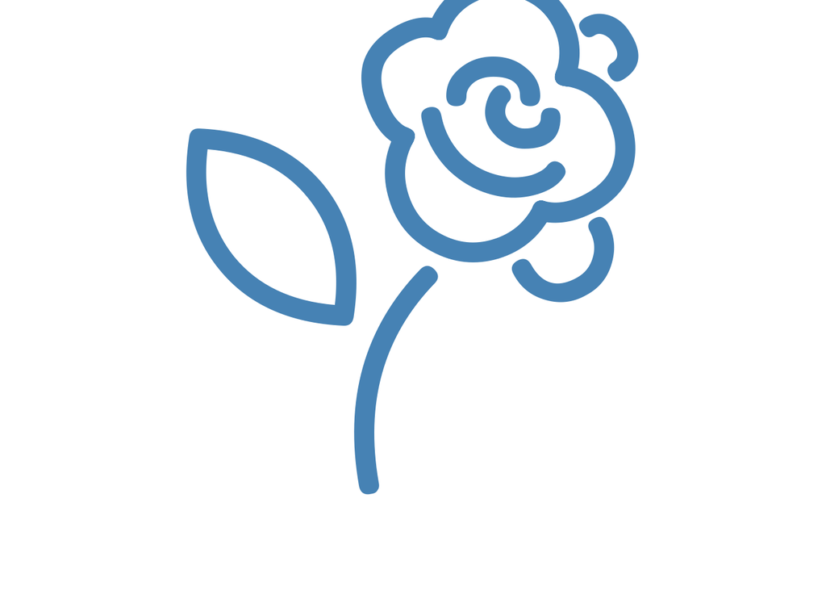

```r
ggplot() + geom_emoji("rose", color = "steelblue") + theme_void()
```

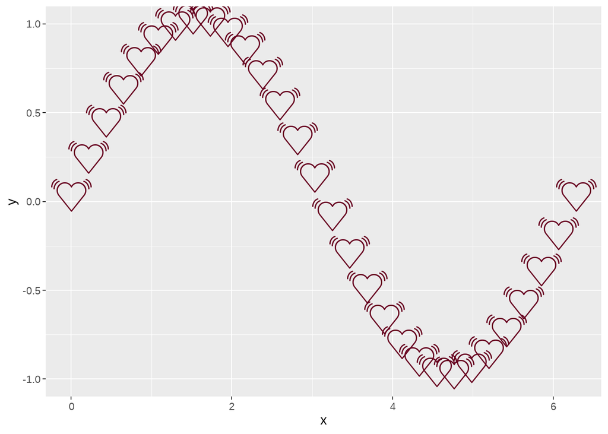

```r
x <- seq(0, 2 * pi, length = 30)
y <- sin(x)
ggplot() + geom_emoji("heartbeat", x = x, y = y, size = 10)
```

# Emoji in tables

You can also use emoji within HTML tables by placing Unicode emoji into cells. Here we use `knitr::kable()` to render a simple table.

```r
library(emojifont)
library(knitr)

df <- data.frame(
  name  = c("Cow", "Camel", "Heartbeat"),
  emoji = emoji(c("cow", "camel", "heartbeat")),
  stringsAsFactors = FALSE
)

kable(df, format = "html")
```

| name | emoji |
| --- | --- |
| Cow | 🐮 |
| Camel | 🐫 |
| Heartbeat | 💓 |

# Font Awesome

The package also supports Font Awesome icons.

[figure not shown]

```r
library(ggplot2)
set.seed(20160309)
fa <- fontawesome(c("fa-github", "fa-weibo", "fa-twitter", "fa-android", "fa-coffee"))
d <- data.frame(
  x = rnorm(20),
  y = rnorm(20),
  label = sample(fa, 20, replace = TRUE)
)

ggplot(d, aes(x, y, color = label, label = label)) +
  geom_text(family = "fontawesome-webfont", size = 6) +
  xlab(NULL) + ylab(NULL) +
  theme(legend.text = element_text(family = "fontawesome-webfont"))
```

A corresponding `geom_fontawesome` is also provided.

[figure not shown]

```r
ggplot() + geom_fontawesome("fa-github", color = "black") + theme_void()
```

# phylomoji

Creating phylomoji is possible using `emojifont` and `ggtree`, please refer to: https://yulab-smu.top/treedata-book/chapter8.html#phylomoji.

# Limitation

RStudio uses a different graphics device handling and `showtext` may be incompatible with it. Since `emojifont` uses `showtext` as backend to parse emoji font, it may also be incompatible with RStudio. Consider manually opening a device (`X11()` in Linux, `quartz()` in macOS or `windows()` in Windows).

# Note

Currently, this package supports Emoji Font and Font Awesome.

- `OpenMoji-Black.ttf` is downloaded from https://github.com/hfg-gmuend/openmoji
- `fontawesome-webfont.ttf` is downloaded from https://github.com/FortAwesome/Font-Awesome.

Feel free to fork this package to add your favorite iconic fonts.

# Bugs/Feature requests

If you have any, let me know: https://github.com/GuangchuangYu/emojifont/issues.